# Swiss REOC Firm-Level Development

Analysis draft

02 September 2026

# 1 1. Objective

This document develops a first exploratory framework for analysing Swiss real-estate operating companies (REOCs) at the **firm-year level**.

The main question is:

> How does each REOC develop over time, and which financial and market variables are most informative for describing that development?

The analysis uses the two cleaned input files:

- `swiss_reoc_yearly_FA.csv`: annual fundamental/accounting and valuation variables.
- `swiss_reoc_monthly_HP.csv`: monthly market variables and returns.

The first version deliberately focuses on **descriptive analysis**. It does not yet make causal claims.

# 2 2. Packages and data

```r
library(tidyverse)
library(janitor)
library(lubridate)
library(knitr)
library(scales)

theme_set(theme_minimal())

fa <- read_csv("../Dataset 1 excel/swiss_reoc_yearly_FA.csv", show_col_types = FALSE) |>
  clean_names()


hp <- read_csv("../Dataset 1 excel/swiss_reoc_monthly_HP.csv", show_col_types = FALSE) |>
  clean_names()

fa <- fa |>
  mutate(year = as.integer(year))

hp <- hp |>
  mutate(
    date = as.Date(date),
    year = year(date)
  )
```

# 3 3. Initial data audit

## 3.1 3.1 Dataset structure

```r
data_overview <- tibble(
  dataset = c("Annual fundamentals", "Monthly market data"),
  rows = c(nrow(fa), nrow(hp)),
  firms = c(n_distinct(fa$ticker), n_distinct(hp$ticker)),
  first_date_or_year = c(min(fa$year, na.rm = TRUE), min(hp$date, na.rm = TRUE)),
  last_date_or_year = c(max(fa$year, na.rm = TRUE), max(hp$date, na.rm = TRUE))
)

kable(data_overview)
```

| dataset | rows | firms | first_date_or_year | last_date_or_year |
| --- | --- | --- | --- | --- |
| Annual fundamentals | 214 | 11 | 2001 | 2027 |
| Monthly market data | 2224 | 11 | 10987 | 20573 |

The annual dataset contains one observation per firm-year, while the monthly dataset contains one observation per firm-month.

```r
duplicates <- tibble(
  annual_duplicate_ticker_year = sum(duplicated(fa[c("ticker", "year")])),
  monthly_duplicate_ticker_date = sum(duplicated(hp[c("ticker", "date")]))
)

kable(duplicates)
```

| annual_duplicate_ticker_year | monthly_duplicate_ticker_date |
| --- | --- |
| 0 | 0 |

## 3.2 3.2 Firm coverage

```r
firm_coverage <- fa |>
  group_by(ticker) |>
  summarise(
    first_year = min(year, na.rm = TRUE),
    last_year = max(year, na.rm = TRUE),
    n_years = n(),
    .groups = "drop"
  ) |>
  arrange(first_year, ticker)

kable(firm_coverage)
```

| ticker | first_year | last_year | n_years |
| --- | --- | --- | --- |
| ALLN | 2001 | 2027 | 27 |
| ISN | 2001 | 2027 | 27 |
| PSPN | 2001 | 2027 | 27 |
| SPSN | 2001 | 2027 | 27 |
| MOBN | 2004 | 2027 | 24 |
| ZUGEST | 2011 | 2027 | 17 |
| ZUGN | 2011 | 2027 | 17 |
| HIAG | 2012 | 2027 | 16 |
| IREN | 2013 | 2027 | 15 |
| EPIC | 2019 | 2027 | 9 |
| CHAM | 2020 | 2027 | 8 |

This matters because the panel is **unbalanced**: some REOCs are observed for much longer than others. Therefore, changes in the aggregate sample can reflect both genuine firm development and the entry of additional firms.

# 4 4. Which variables are most interesting?

The variables naturally fall into four groups.

## 4.1 4.1 Core financial development variables

These should be the main variables for the firm-year analysis:

1. **Total assets (`fa_total_assets`)** — captures firm scale and balance-sheet growth.
2. **Net income (`net_income`)** — captures profitability in absolute terms.
3. **Dividend per share (`dividend_per_share`)** — captures shareholder distribution.
4. **Debt-to-assets (`debt_to_assets`)** — captures balance-sheet leverage.
5. **Net debt / EBITDA (`net_debt_ebitda`)** — captures debt burden relative to operating earnings.

These variables together give a useful picture of **growth, profitability, shareholder distributions and financial risk**.

## 4.2 4.2 Market variables

From the monthly dataset, the most useful variables are:

1. **Market capitalization (`market_cap`)** — firm size from the market’s perspective.
2. **Price (`price`)** — share-price development.
3. **Total return index (`total_return_index`)** — preferred for measuring investor performance.
4. **Monthly return (`monthly_return`)** — used to construct annual returns.

The total return index is especially important because it captures a broader investor return measure than price alone.

## 4.3 4.3 Secondary valuation/profitability variables

The annual file also contains:

- `dividend_yield`
- `pe_ratio`
- `profit_margin`

These are potentially interesting, but they should **not be treated as core variables in the first analysis** because their availability is much more limited in the supplied data. We therefore report their coverage first and use them only where observations are sufficiently available.

```r
key_vars <- c(
  "fa_total_assets", "net_income", "dividend_per_share",
  "debt_to_assets", "net_debt_ebitda",
  "dividend_yield", "pe_ratio", "profit_margin"
)

missingness <- fa |>
  summarise(across(all_of(key_vars), ~ mean(is.na(.)))) |>
  pivot_longer(everything(), names_to = "variable", values_to = "missing_share") |>
  mutate(
    available_share = 1 - missing_share,
    missing_share = scales::percent(missing_share, accuracy = 0.1),
    available_share = scales::percent(available_share, accuracy = 0.1)
  ) |>
  arrange(desc(as.numeric(gsub("%", "", missing_share))))

kable(missingness)
```

| variable | missing_share | available_share |
| --- | --- | --- |
| dividend_yield | 88.3% | 11.7% |
| pe_ratio | 86.4% | 13.6% |
| profit_margin | 84.6% | 15.4% |
| net_income | 13.6% | 86.4% |
| net_debt_ebitda | 12.1% | 87.9% |
| fa_total_assets | 10.3% | 89.7% |
| dividend_per_share | 10.3% | 89.7% |
| debt_to_assets | 10.3% | 89.7% |

**Interpretation:** the first analysis should concentrate on assets, net income, dividends, leverage and net debt/EBITDA. Valuation variables such as P/E and dividend yield should be treated as secondary because they are sparse in this extract.

# 5 5. Annual firm-year dataset

The core analytical object is one row per **firm-year**.

We add year-on-year changes for the main variables.

```r
firm_year <- fa |>
  select(
    ticker, year,
    fa_total_assets,
    net_income,
    dividend_per_share,
    debt_to_assets,
    net_debt_ebitda,
    dividend_yield,
    pe_ratio,
    profit_margin
  ) |>
  arrange(ticker, year) |>
  group_by(ticker) |>
  mutate(
    assets_yoy = fa_total_assets / lag(fa_total_assets) - 1,
    net_income_yoy = net_income / lag(net_income) - 1,
    dividend_yoy = dividend_per_share / lag(dividend_per_share) - 1,
    debt_to_assets_change = debt_to_assets - lag(debt_to_assets),
    net_debt_ebitda_change = net_debt_ebitda - lag(net_debt_ebitda)
  ) |>
  ungroup()
```

The year-on-year variables are useful because levels answer **“how large/profitable is the firm?”**, while changes answer **“how quickly is the firm changing?”**

# 6 6. Firm development: one firm at a time

A useful first visualisation is to plot the main variables for every firm.

## 6.1 6.1 Total assets

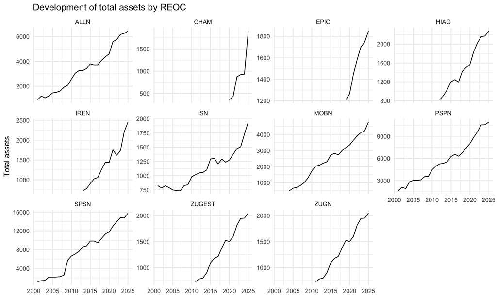

```r
ggplot(
  firm_year |> filter(year <= 2025),
  aes(x = year, y = fa_total_assets, group = ticker)
) +
  geom_line(na.rm = TRUE) +
  facet_wrap(~ ticker, scales = "free_y") +
  labs(
    title = "Development of total assets by REOC",
    x = NULL,
    y = "Total assets"
  )
```

This is the main measure of **firm scale and growth**. Because firms differ substantially in size, `scales = "free_y"` is used to make within-firm trajectories visible.

## 6.2 6.2 Net income

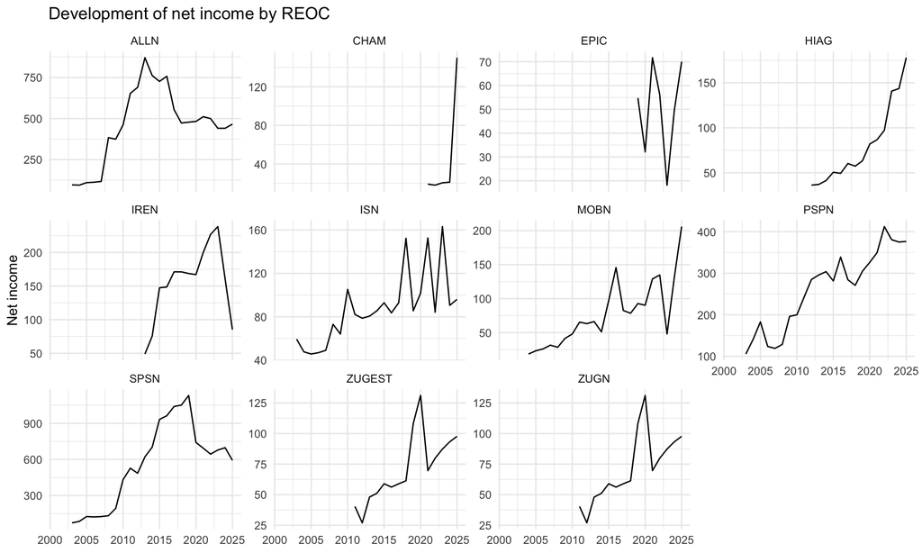

```r
ggplot(
  firm_year |> filter(year <= 2025),
  aes(x = year, y = net_income, group = ticker)
) +
  geom_line(na.rm = TRUE) +
  facet_wrap(~ ticker, scales = "free_y") +
  labs(
    title = "Development of net income by REOC",
    x = NULL,
    y = "Net income"
  )
```

Net income should be interpreted together with assets. A firm can grow its asset base without generating proportionally stronger earnings.

## 6.3 6.3 Dividend per share

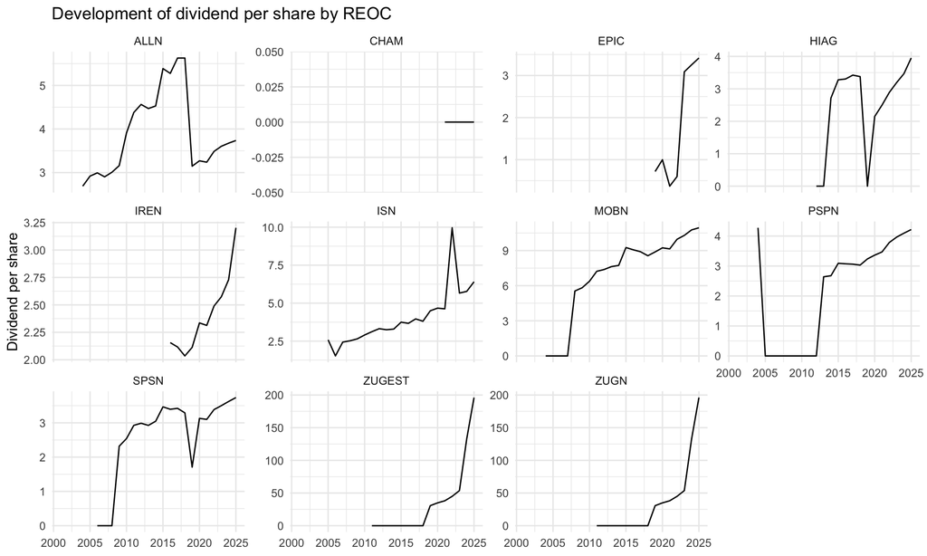

```r
ggplot(
  firm_year |> filter(year <= 2025),
  aes(x = year, y = dividend_per_share, group = ticker)
) +
  geom_line(na.rm = TRUE) +
  facet_wrap(~ ticker, scales = "free_y") +
  labs(
    title = "Development of dividend per share by REOC",
    x = NULL,
    y = "Dividend per share"
  )
```

Dividend per share is useful for identifying firms with stable, growing or volatile shareholder distributions.

## 6.4 6.4 Leverage

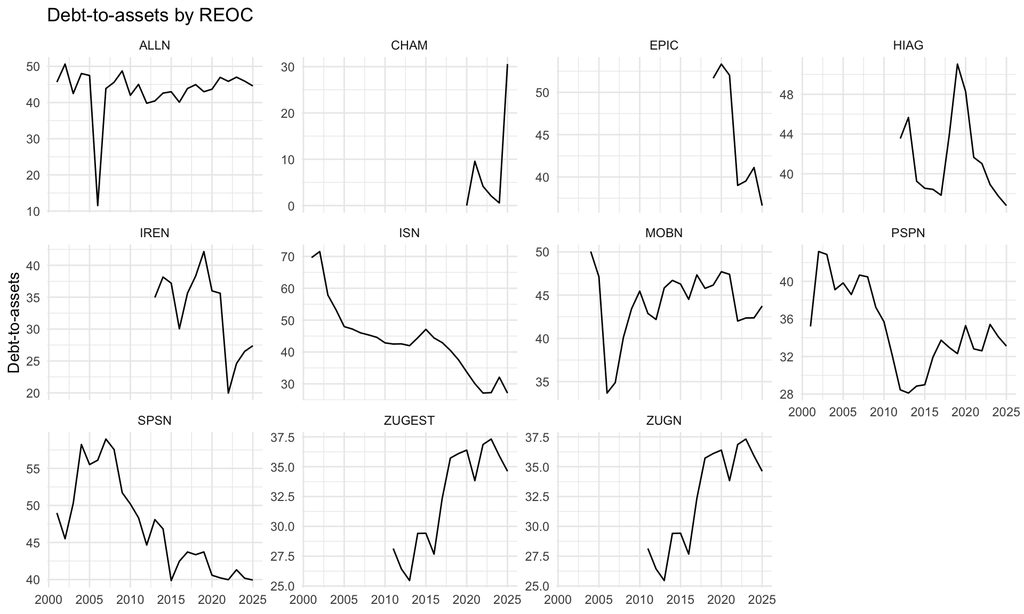

```r
ggplot(
  firm_year |> filter(year <= 2025),
  aes(x = year, y = debt_to_assets, group = ticker)
) +
  geom_line(na.rm = TRUE) +
  facet_wrap(~ ticker, scales = "free_y") +
  labs(
    title = "Debt-to-assets by REOC",
    x = NULL,
    y = "Debt-to-assets"
  )
```

Leverage should be considered jointly with growth and profitability. Increasing leverage can support expansion, but persistent increases can also indicate greater financial risk.

# 7 7. Firm-year growth rates

For comparing firms of different sizes, growth rates are often more informative than levels.

```r
growth_summary <- firm_year |>
  filter(year >= 2005, year <= 2025) |>
  group_by(ticker) |>
  summarise(
    avg_asset_growth = mean(assets_yoy, na.rm = TRUE),
    median_asset_growth = median(assets_yoy, na.rm = TRUE),
    avg_income_growth = mean(net_income_yoy, na.rm = TRUE),
    median_income_growth = median(net_income_yoy, na.rm = TRUE),
    avg_dividend_growth = mean(dividend_yoy, na.rm = TRUE),
    .groups = "drop"
  )

kable(
  growth_summary |>
    mutate(across(where(is.numeric), ~ round(.x, 3)))
)
```

| ticker | avg_asset_growth | median_asset_growth | avg_income_growth | median_income_growth | avg_dividend_growth |
| --- | --- | --- | --- | --- | --- |
| ALLN | 0.085 | 0.070 | 0.138 | 0.023 | 0.025 |
| CHAM | 0.469 | 0.221 | 1.548 | 0.083 | NaN |
| EPIC | 0.074 | 0.066 | 0.345 | 0.097 | 0.774 |
| HIAG | 0.084 | 0.066 | 0.138 | 0.115 | Inf |
| IREN | 0.111 | 0.120 | 0.101 | 0.030 | 0.047 |
| ISN | 0.046 | 0.032 | 0.093 | 0.045 | 0.086 |
| MOBN | 0.118 | 0.086 | 0.212 | 0.156 | Inf |
| PSPN | 0.068 | 0.069 | 0.062 | 0.038 | Inf |
| SPSN | 0.118 | 0.071 | 0.131 | 0.053 | Inf |
| ZUGEST | 0.078 | 0.073 | 0.112 | 0.066 | Inf |
| ZUGN | 0.078 | 0.073 | 0.112 | 0.066 | Inf |

Large year-on-year changes should be inspected individually rather than automatically interpreted as structural growth. They can arise from acquisitions, disposals, restructurings, one-off gains/losses or changes in the underlying accounting data.

# 8 8. Long-run firm development

A compact way to describe each firm is to compare its first and last available historical observation.

For comparability, the initial version uses **2001–2025 as the historical window**. The 2026–2027 observations in the annual file are not treated as ordinary historical observations because coverage is incomplete and the monthly market dataset currently ends in April 2026.

```r
long_run <- firm_year |>
  filter(year <= 2025) |>
  group_by(ticker) |>
  summarise(
    first_year = min(year[!is.na(fa_total_assets)]),
    last_year = max(year[!is.na(fa_total_assets)]),
    assets_start = first(fa_total_assets[!is.na(fa_total_assets)]),
    assets_end = last(fa_total_assets[!is.na(fa_total_assets)]),
    net_income_start = first(net_income[!is.na(net_income)]),
    net_income_end = last(net_income[!is.na(net_income)]),
    dividend_start = first(dividend_per_share[!is.na(dividend_per_share)]),
    dividend_end = last(dividend_per_share[!is.na(dividend_per_share)]),
    .groups = "drop"
  ) |>
  mutate(
    asset_cagr = (assets_end / assets_start)^(1 / (last_year - first_year)) - 1,
    net_income_cagr = (net_income_end / net_income_start)^(1 / (last_year - first_year)) - 1,
    dividend_cagr = if_else(
      dividend_start > 0 & dividend_end > 0,
      (dividend_end / dividend_start)^(1 / (last_year - first_year)) - 1,
      NA_real_
    )
  )

kable(
  long_run |>
    mutate(
      asset_cagr = scales::percent(asset_cagr, accuracy = 0.1),
      net_income_cagr = scales::percent(net_income_cagr, accuracy = 0.1),
      dividend_cagr = scales::percent(dividend_cagr, accuracy = 0.1)
    )
)
```

| ticker | first_year | last_year | assets_start | assets_end | net_income_start | net_income_end | dividend_start | dividend_end | asset_cagr | net_income_cagr | dividend_cagr |
| --- | --- | --- | --- | --- | --- | --- | --- | --- | --- | --- | --- |
| ALLN | 2001 | 2025 | 907.4115 | 6441.653 | 96.5834 | 466.1904 | 2.6886 | 3.7364 | 8.5% | 6.8% | 1.4% |
| CHAM | 2020 | 2025 | 355.0206 | 1904.658 | 19.1340 | 150.0616 | 0.0000 | 0.0000 | 39.9% | 51.0% | NA |
| EPIC | 2019 | 2025 | 1208.5584 | 1848.726 | 54.7842 | 70.0257 | 0.7193 | 3.4161 | 7.3% | 4.2% | 29.6% |
| HIAG | 2012 | 2025 | 817.8782 | 2276.056 | 36.2856 | 177.8420 | 0.0000 | 3.9499 | 8.2% | 13.0% | NA |
| IREN | 2013 | 2025 | 724.7767 | 2454.255 | 48.9348 | 85.2006 | 2.1562 | 3.2026 | 10.7% | 4.7% | 3.4% |
| ISN | 2001 | 2025 | 823.8530 | 1941.161 | 59.4277 | 96.0137 | 2.5830 | 6.4052 | 3.6% | 2.0% | 3.9% |
| MOBN | 2004 | 2025 | 498.1389 | 4768.024 | 18.5444 | 205.9725 | 0.0000 | 10.9422 | 11.4% | 12.1% | NA |
| PSPN | 2001 | 2025 | 1621.3952 | 10929.104 | 105.5660 | 376.5285 | 4.2757 | 4.2167 | 8.3% | 5.4% | -0.1% |
| SPSN | 2001 | 2025 | 1178.3410 | 15780.759 | 72.6389 | 592.4642 | 0.0000 | 3.7364 | 11.4% | 9.1% | NA |
| ZUGEST | 2011 | 2025 | 730.1436 | 2048.200 | 40.3714 | 97.6811 | 0.0000 | 196.1159 | 7.6% | 6.5% | NA |
| ZUGN | 2011 | 2025 | 730.1436 | 2048.200 | 40.3714 | 97.6811 | 0.0000 | 196.1159 | 7.6% | 6.5% | NA |

The long-run table is a **descriptive ranking**, not a performance league table. Firms have different starting dates and business histories.

# 9 9. Cross-sectional development by year

The next question is how the typical REOC changed over time.

Because the panel is unbalanced, it is useful to show both:

- the number of firms available in each year;
- the median value across firms.

Medians are preferred to means for the first pass because the firms differ considerably in size.

```r
annual_summary <- firm_year |>
  filter(year <= 2025) |>
  group_by(year) |>
  summarise(
    n_firms = n_distinct(ticker),
    median_assets = median(fa_total_assets, na.rm = TRUE),
    median_net_income = median(net_income, na.rm = TRUE),
    median_dividend = median(dividend_per_share, na.rm = TRUE),
    median_debt_to_assets = median(debt_to_assets, na.rm = TRUE),
    median_net_debt_ebitda = median(net_debt_ebitda, na.rm = TRUE),
    .groups = "drop"
  )

kable(annual_summary |> mutate(across(where(is.numeric), ~ round(.x, 2))))
```

| year | n_firms | median_assets | median_net_income | median_dividend | median_debt_to_assets | median_net_debt_ebitda |
| --- | --- | --- | --- | --- | --- | --- |
| 2001 | 4 | 1042.88 | NA | NA | 47.32 | 8.07 |
| 2002 | 4 | 1302.40 | NA | NA | 48.07 | 10.53 |
| 2003 | 4 | 1258.81 | 84.61 | NA | 46.57 | 11.09 |
| 2004 | 5 | 1212.85 | 84.91 | 1.34 | 50.04 | 10.53 |
| 2005 | 5 | 1459.32 | 110.04 | 1.29 | 47.48 | 10.00 |
| 2006 | 5 | 1506.35 | 112.53 | 0.00 | 38.60 | 10.28 |
| 2007 | 5 | 1612.49 | 117.35 | 0.00 | 43.87 | 9.09 |
| 2008 | 5 | 1918.20 | 128.68 | 2.52 | 45.35 | 8.55 |
| 2009 | 5 | 2075.22 | 193.71 | 2.65 | 44.59 | 8.36 |
| 2010 | 5 | 2578.73 | 199.87 | 2.90 | 42.87 | 7.18 |
| 2011 | 7 | 2036.85 | 82.20 | 2.93 | 42.50 | 5.69 |
| 2012 | 8 | 1568.25 | 70.95 | 1.49 | 41.00 | 6.45 |
| 2013 | 9 | 1058.34 | 66.29 | 2.78 | 40.44 | 6.30 |
| 2014 | 9 | 1101.81 | 75.59 | 2.88 | 39.25 | 7.79 |
| 2015 | 9 | 1293.22 | 97.37 | 3.37 | 38.54 | 7.33 |
| 2016 | 9 | 1302.16 | 145.57 | 3.30 | 38.43 | 6.88 |
| 2017 | 9 | 1215.02 | 92.98 | 3.42 | 37.84 | 8.71 |
| 2018 | 9 | 1420.64 | 152.25 | 3.29 | 40.50 | 8.61 |
| 2019 | 10 | 1525.06 | 108.24 | 3.19 | 42.58 | 7.79 |
| 2020 | 11 | 1502.78 | 131.17 | 3.32 | 36.39 | 10.11 |
| 2021 | 11 | 1754.36 | 128.96 | 3.24 | 35.62 | 6.54 |
| 2022 | 11 | 1814.86 | 97.22 | 3.49 | 36.86 | 9.30 |
| 2023 | 11 | 1945.97 | 140.75 | 3.60 | 37.32 | 17.79 |
| 2024 | 11 | 2170.25 | 131.45 | 3.67 | 35.90 | 7.93 |
| 2025 | 11 | 2276.06 | 150.06 | 3.95 | 34.62 | 6.04 |

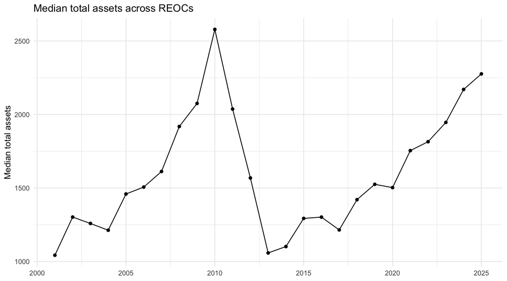

```r
ggplot(annual_summary, aes(year, median_assets)) +
  geom_line() +
  geom_point() +
  labs(
    title = "Median total assets across REOCs",
    x = NULL,
    y = "Median total assets"
  )
```

# 10 10. Connecting fundamentals to market development

The monthly file allows us to construct annual market measures.

For each firm-year we calculate:

- annual total return;
- year-end market capitalization;
- average monthly return.

The annual total return is calculated from the total return index and is therefore preferable to simply using the change in price.

```r
hp_annual <- hp |>
  group_by(ticker, year) |>
  arrange(date, .by_group = TRUE) |>
  summarise(
    year_end_date = max(date, na.rm = TRUE),
    year_end_market_cap = market_cap[which.max(date)],
    year_end_tri = total_return_index[which.max(date)],
    .groups = "drop"
  ) |>
  arrange(ticker, year) |>
  group_by(ticker) |>
  mutate(
    annual_total_return = year_end_tri / lag(year_end_tri) - 1
  ) |>
  ungroup()
```

The fundamental and market datasets can then be combined at the firm-year level.

```r
firm_year_market <- firm_year |>
  left_join(
    hp_annual |>
      select(ticker, year, year_end_market_cap, annual_total_return),
    by = c("ticker", "year")
  )
```

## 10.1 10.1 Annual total return by firm

Market performance provides a complementary perspective to the accounting variables. The following figure shows how annual total returns developed for each REOC.

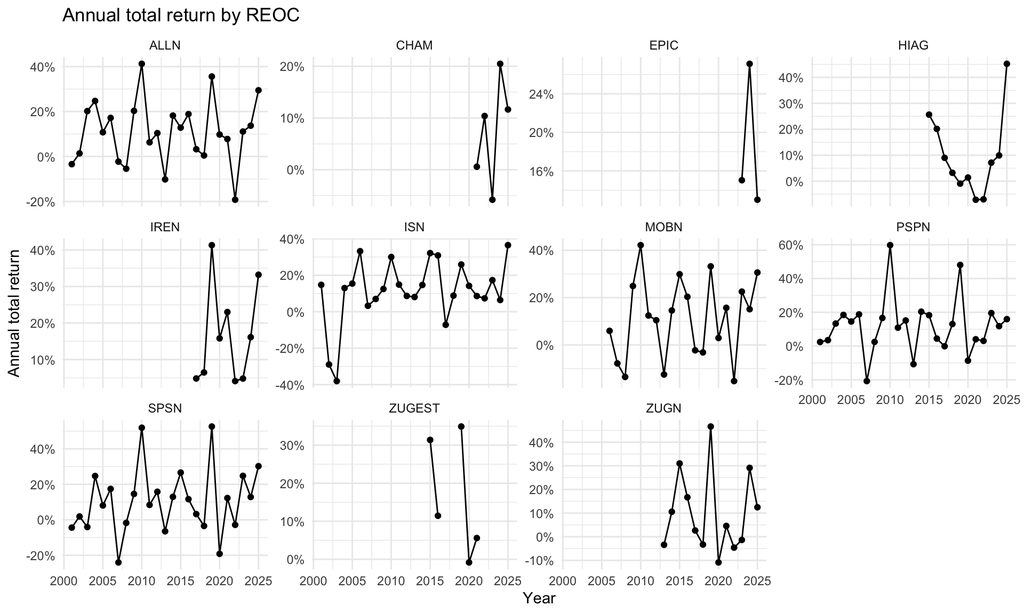

```r
ggplot(
  firm_year_market |> filter(year <= 2025),
  aes(x = year, y = annual_total_return, group = ticker)
) +
  geom_line(na.rm = TRUE) +
  geom_point(na.rm = TRUE) +
  facet_wrap(~ ticker, scales = "free_y") +
  scale_y_continuous(labels = scales::percent) +
  labs(
    title = "Annual total return by REOC",
    x = "Year",
    y = "Annual total return"
  )
```

This plot allows us to compare the market performance of individual REOCs over time. It should be interpreted alongside the fundamental variables rather than on its own.

## 10.2 10.2 Assets and market capitalisation

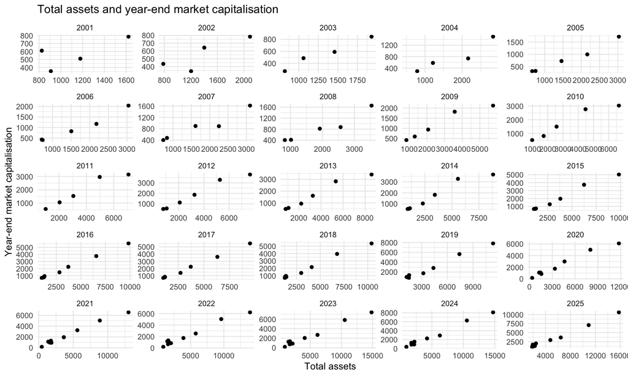

```r
ggplot(
  firm_year_market |> filter(year <= 2025),
  aes(x = fa_total_assets, y = year_end_market_cap)
) +
  geom_point(na.rm = TRUE) +
  facet_wrap(~ year, scales = "free") +
  labs(
    title = "Total assets and year-end market capitalisation",
    x = "Total assets",
    y = "Year-end market capitalisation"
  )
```

This is a descriptive relationship only. A stronger analysis would need to account for firm-specific effects, market conditions and timing.

## 10.3 10.3 Profitability and subsequent market return

For a later stage, it is more interesting to relate **information known in year t** to market performance in year t+1.

```r
lagged_analysis <- firm_year_market |>
  arrange(ticker, year) |>
  group_by(ticker) |>
  mutate(
    next_year_return = lead(annual_total_return),
    next_year_market_cap = lead(year_end_market_cap)
  ) |>
  ungroup()
```

## 10.4 10.4 Net income growth and subsequent return

A more informative relationship is between the change in fundamentals in year *t* and market performance in year *t+1*.

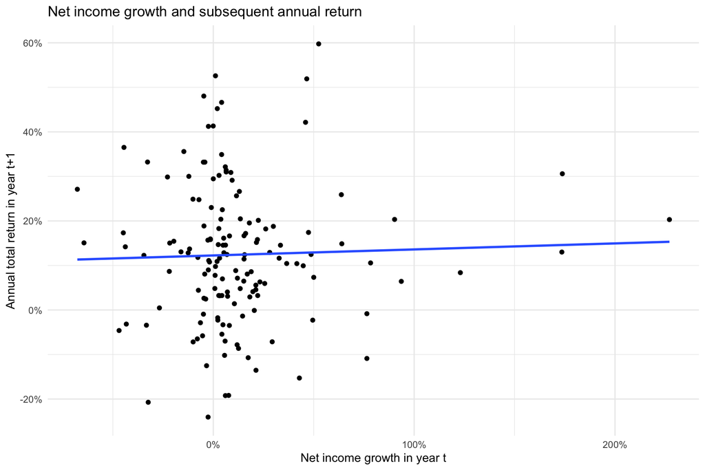

```r
ggplot(
  lagged_analysis |>
    filter(year <= 2024, is.finite(net_income_yoy), is.finite(next_year_return)),
  aes(x = net_income_yoy, y = next_year_return)
) +
  geom_point(na.rm = TRUE) +
  geom_smooth(method = "lm", se = FALSE, na.rm = TRUE) +
  scale_x_continuous(labels = scales::percent) +
  scale_y_continuous(labels = scales::percent) +
  labs(
    title = "Net income growth and subsequent annual return",
    x = "Net income growth in year t",
    y = "Annual total return in year t+1"
  )
```

This is an exploratory relationship and does not by itself establish causality.

## 10.5 10.5 Leverage change and subsequent return

The same idea can be applied to leverage.

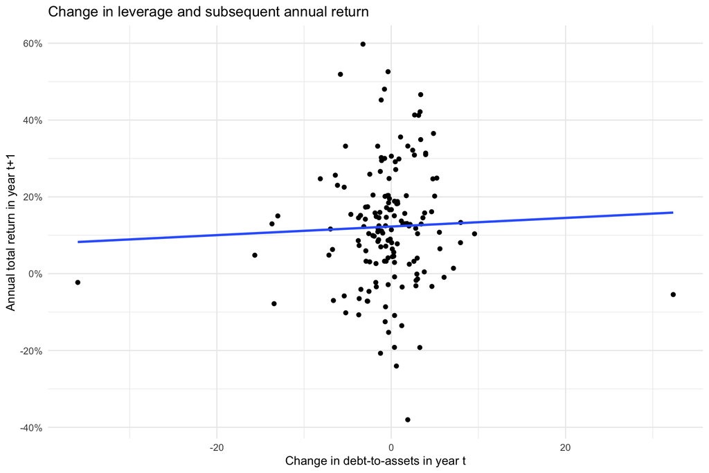

```r
ggplot(
  lagged_analysis |>
    filter(year <= 2024, is.finite(debt_to_assets_change), is.finite(next_year_return)),
  aes(x = debt_to_assets_change, y = next_year_return)
) +
  geom_point(na.rm = TRUE) +
  geom_smooth(method = "lm", se = FALSE, na.rm = TRUE) +
  scale_y_continuous(labels = scales::percent) +
  labs(
    title = "Change in leverage and subsequent annual return",
    x = "Change in debt-to-assets in year t",
    y = "Annual total return in year t+1"
  )
```

Again, this is descriptive and exploratory. A regression analysis would be needed to investigate whether the relationship remains after controlling for firm and year effects.

This creates a cleaner basis for future predictive tests, because the fundamental variable is measured before the subsequent return.

# 11 11. Variables to keep for the main analysis

The recommended first specification is:

| Role | Variable | Why it matters |
| --- | --- | --- |
| Firm size | `fa_total_assets` | Balance-sheet scale and growth |
| Profitability | `net_income` | Absolute earnings |
| Shareholder distribution | `dividend_per_share` | Dividend policy |
| Leverage | `debt_to_assets` | Balance-sheet risk |
| Debt burden | `net_debt_ebitda` | Debt relative to earnings |
| Market size | `year_end_market_cap` | Market valuation/size |
| Market performance | `annual_total_return` | Investor return |
| Market price | `price` | Price development |
| Secondary | `profit_margin` | Relative profitability, but sparse |
| Secondary | `pe_ratio` | Valuation, but sparse |
| Secondary | `dividend_yield` | Income valuation, but sparse |

# 12 12. Important data-quality observations

The annual file contains observations for **2026 and 2027**, but the coverage of the core accounting variables is incomplete in those years. The monthly market file currently runs only through April 2026.

Therefore, this first historical analysis uses **2001–2025** for the main long-run comparisons.

The annual panel is also unbalanced because firms enter the dataset at different dates. This means that aggregate yearly statistics should always be accompanied by the number of firms observed.

Missing values should not automatically be converted to zero. In particular, a missing dividend is not necessarily equivalent to a zero dividend.

# 13 13. Prepare Panel A: monthly HP + monthly macro -> market response

RQ2: How is the stock-market performance of Swiss listed real-estate companies associated with changes in the macroeconomic environment?

This section investigates the relationship between monthly returns of Swiss listed real-estate companies and selected monthly macroeconomic indicators, including interest rates, bond yields, and unemployment.

# 14 14 Objective

This document develops the **market-response panel** for the Swiss REOC project.

The guiding question is:

> RQ2: How is the stock-market performance of Swiss listed real-estate companies associated with changes in the macroeconomic environment?

Concretely, the analysis works through, depending on what is actually available in the macro dataset:

- interest rates vs. monthly returns,
- inflation vs. returns,
- other macro indicators (real estate price indices, labour market) vs. returns,
- volatility of returns,
- differences across time / macro regimes,
- differences across firms.

As in the firm-level document, this first pass is **descriptive and exploratory**. It documents associations, not causal effects.

```r
library(tidyverse)
library(janitor)
library(lubridate)
library(knitr)
library(scales)
library(broom)

theme_set(theme_minimal())

macro_file <- "../Data cleaning/swiss_reoc_monthly_HP_macro.csv.csv"

hp <- read_csv("../Dataset 1 excel/swiss_reoc_monthly_HP.csv", show_col_types = FALSE) |>
  clean_names()

hp_macro <- read_csv(macro_file, show_col_types = FALSE) |>
  clean_names()

hp_macro <- hp_macro |>
  mutate(
    date  = as.Date(date),
    month = floor_date(date, "month")
  )
```

# 15 15 Initial data audit

## 15.1 15.1 Panel structure

```r
data_overview <- tibble(
  rows       = nrow(hp_macro),
  firms      = n_distinct(hp_macro$ticker),
  months     = n_distinct(hp_macro$month),
  first_date = min(hp_macro$date, na.rm = TRUE),
  last_date  = max(hp_macro$date, na.rm = TRUE)
)

kable(data_overview)
```

| rows | firms | months | first_date | last_date |
| --- | --- | --- | --- | --- |
| 2224 | 11 | 316 | 2000-01-31 | 2026-04-30 |

The macro variables are recorded at the month level and are identical across all firms observed in the same month. This means the panel is currently “long” (one row per firm-month), so macro variables must be de-duplicated before any month-level analysis, otherwise firms with more coverage would silently over-weight certain months.

```r
hp_macro |>
  filter(month == as.Date("2010-06-01")) |>
  distinct(confederation_10y, sfso_inflation_according_to_the_national_consumer_price_index, jobless_rate_total) |>
  kable(caption = "Sanity check: macro values are constant within a month across firms")
```

Sanity check: macro values are constant within a month across firms

| confederation_10y | sfso_inflation_according_to_the_national_consumer_price_index | jobless_rate_total |
| --- | --- | --- |
| 1.559182 | 0.5 | 3.34204 |

## 15.2 15.2 Firm coverage

```r
firm_coverage <- hp_macro |>
  filter(!is.na(monthly_return)) |>
  group_by(ticker) |>
  summarise(
    first_month = min(month),
    last_month  = max(month),
    n_months    = n(),
    .groups = "drop"
  ) |>
  arrange(first_month, ticker)

kable(firm_coverage)
```

| ticker | first_month | last_month | n_months |
| --- | --- | --- | --- |
| ISN | 2000-02-01 | 2026-04-01 | 315 |
| ALLN | 2000-04-01 | 2026-04-01 | 313 |
| PSPN | 2000-04-01 | 2026-04-01 | 313 |
| SPSN | 2000-05-01 | 2026-04-01 | 312 |
| MOBN | 2005-07-01 | 2026-04-01 | 250 |
| ZUGN | 2012-08-01 | 2026-04-01 | 165 |
| ZUGEST | 2012-11-01 | 2026-03-01 | 161 |
| HIAG | 2014-06-01 | 2026-04-01 | 143 |
| IREN | 2016-07-01 | 2026-04-01 | 118 |
| CHAM | 2020-07-01 | 2026-04-01 | 70 |
| EPIC | 2022-06-01 | 2026-04-01 | 47 |

As in the firm-level panel, coverage is unbalanced: firms enter the sample at different points, so portfolio-level statistics in early years rest on fewer firms than in later years.

# 16 16 Which macro variables are available?

```r
macro_monthly <- hp_macro |>
  distinct(month, .keep_all = TRUE) |>
  select(
    month,
    snb_target_lower, snb_target_upper, libor_3m_chf, snb_policy_rate,
    confederation_5y, confederation_8y, confederation_10y, confederation_bonds,
    mortgage_bond_institutions,
    jobless_rate_total, jobless_rate_sa, job_vacancies_sa,
    snb_core_inflation_trimmed_mean1, sfso_core_inflation_12, sfso_core_inflation_23,
    sfso_inflation_according_to_the_national_consumer_price_index,
    apartments_fso, apartments_wuest_transaction, apartments_wuest_asking,
    houses_fso, houses_wuest_transaction, houses_wuest_asking,
    commercial_office_wuest_asking, commercial_retail_wuest_asking,
    gdp
  ) |>
  arrange(month)

macro_missingness <- macro_monthly |>
  summarise(across(-month, ~ mean(is.na(.)))) |>
  pivot_longer(everything(), names_to = "variable", values_to = "missing_share") |>
  mutate(missing_share_pct = percent(missing_share, accuracy = 0.1)) |>
  arrange(missing_share)

kable(macro_missingness |> select(variable, missing_share_pct))
```

| variable | missing_share_pct |
| --- | --- |
| jobless_rate_total | 0.0% |
| jobless_rate_sa | 0.0% |
| job_vacancies_sa | 0.0% |
| snb_core_inflation_trimmed_mean1 | 0.0% |
| sfso_inflation_according_to_the_national_consumer_price_index | 0.0% |
| apartments_wuest_transaction | 0.9% |
| apartments_wuest_asking | 0.9% |
| houses_wuest_transaction | 0.9% |
| houses_wuest_asking | 0.9% |
| commercial_office_wuest_asking | 0.9% |
| commercial_retail_wuest_asking | 0.9% |
| confederation_5y | 2.8% |
| confederation_8y | 2.8% |
| confederation_10y | 2.8% |
| confederation_bonds | 2.8% |
| mortgage_bond_institutions | 2.8% |
| sfso_core_inflation_12 | 5.1% |
| sfso_core_inflation_23 | 5.1% |
| snb_target_lower | 25.9% |
| snb_target_upper | 25.9% |
| libor_3m_chf | 25.9% |
| apartments_fso | 64.6% |
| houses_fso | 64.6% |
| gdp | 66.8% |
| snb_policy_rate | 73.7% |

Interpretation:

- Inflation and labour market series are essentially complete over the whole sample.
- Real-estate price indices (Wuest Partner, Fahrlander, IAZI style series) are almost complete; the FSO indices are considerably sparser and are treated as secondary.
- Interest rates are complete only in pieces: `libor_3m_chf` / `snb_target_lower` cover 2000 to mid-2019, and `snb_policy_rate` covers mid-2019 onward, matching the actual 2019 change in the SNB’s operational target. `confederation_10y` is available almost throughout and is used as the long-rate series.
- GDP and sector output variables are missing about two-thirds of the time and are treated as secondary/contextual only.

## 16.1 16.1 Constructing a continuous short-rate series

```r
macro_monthly <- macro_monthly |>
  mutate(
    short_rate = coalesce(libor_3m_chf, snb_policy_rate),
    long_rate  = confederation_10y
  )

macro_monthly |>
  filter(month >= as.Date("2019-01-01"), month <= as.Date("2019-12-01")) |>
  select(month, libor_3m_chf, snb_policy_rate, short_rate) |>
  kable(caption = "Splice check around the 2019 change in the SNB's reference rate")
```

Splice check around the 2019 change in the SNB’s reference rate

| month | libor_3m_chf | snb_policy_rate | short_rate |
| --- | --- | --- | --- |
| 2019-01-01 | -0.7040000 | NA | -0.7040000 |
| 2019-02-01 | -0.7134700 | NA | -0.7134700 |
| 2019-03-01 | -0.7071714 | NA | -0.7071714 |
| 2019-04-01 | -0.7153900 | NA | -0.7153900 |
| 2019-05-01 | -0.7125810 | NA | -0.7125810 |
| 2019-06-01 | -0.7112000 | -0.75 | -0.7112000 |
| 2019-07-01 | NA | -0.75 | -0.7500000 |
| 2019-08-01 | NA | -0.75 | -0.7500000 |
| 2019-09-01 | NA | -0.75 | -0.7500000 |
| 2019-10-01 | NA | -0.75 | -0.7500000 |
| 2019-11-01 | NA | -0.75 | -0.7500000 |
| 2019-12-01 | NA | -0.75 | -0.7500000 |

## 16.2 16.2 Core macro variables and their changes

```r
macro_monthly <- macro_monthly |>
  arrange(month) |>
  mutate(
    d_short_rate      = short_rate - lag(short_rate),
    d_long_rate       = long_rate - lag(long_rate),
    d_jobless_rate    = jobless_rate_sa - lag(jobless_rate_sa),
    inflation         = sfso_inflation_according_to_the_national_consumer_price_index,
    core_inflation    = snb_core_inflation_trimmed_mean1,
    apartments_growth = apartments_wuest_transaction / lag(apartments_wuest_transaction) - 1,
    houses_growth     = houses_wuest_transaction / lag(houses_wuest_transaction) - 1
  )
```

# 17 17. Portfolio-level market performance

```r
portfolio_data <- hp |>
  mutate(month = floor_date(date, "month")) |>
  arrange(ticker, month) |>
  group_by(ticker) |>
  mutate(lag_market_cap = lag(market_cap)) |>
  ungroup()

portfolio_ew <- portfolio_data |>
  filter(!is.na(monthly_return)) |>
  group_by(month) |>
  summarise(
    ew_return = mean(monthly_return, na.rm = TRUE),
    n_firms   = n_distinct(ticker),
    .groups = "drop"
  )

portfolio_vw <- portfolio_data |>
  filter(!is.na(monthly_return), !is.na(lag_market_cap), lag_market_cap > 0) |>
  group_by(month) |>
  summarise(
    vw_return = weighted.mean(monthly_return, lag_market_cap, na.rm = TRUE),
    .groups = "drop"
  )

portfolio <- portfolio_ew |>
  inner_join(portfolio_vw, by = "month") |>
  arrange(month) |>
  filter(is.finite(ew_return), is.finite(vw_return))
```

## 17.1 17.1 Merging portfolio returns with the macro panel

```r
portfolio_macro <- portfolio |>
  left_join(macro_monthly, by = "month") |>
  arrange(month)

glimpse(
  portfolio_macro |>
    select(month, ew_return, vw_return, short_rate, long_rate, inflation, jobless_rate_sa)
)
```

```
## Rows: 315
## Columns: 7
## $ month           <date> 2000-02-01, 2000-03-01, 2000-04-01, 2000-05-01, 2000-…
## $ ew_return       <dbl> -0.0038558371, 0.0092717387, 0.0178006542, -0.02372548…
## $ vw_return       <dbl> -0.0038558371, 0.0092717387, 0.0277734554, -0.01397511…
## $ short_rate      <dbl> 2.339286, 2.586594, 2.925371, 3.127954, 3.332083, 3.42…
## $ long_rate       <dbl> 3.732524, 3.919739, 3.932556, 4.122045, 4.029300, 3.91…
## $ inflation       <dbl> 1.6, 1.5, 1.4, 1.6, 1.8, 1.9, 1.1, 1.4, 1.3, 1.9, 1.5,…
## $ jobless_rate_sa <dbl> 1.960063, 1.899379, 1.863161, 1.814438, 1.801336, 1.78…
```

## 17.2 17.2 Return and rate levels over time

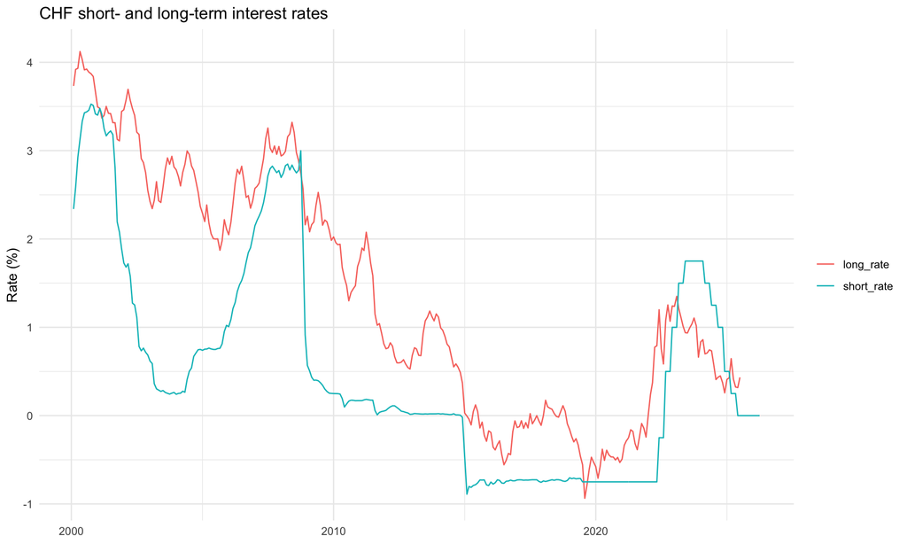

```r
portfolio_macro |>
  pivot_longer(c(short_rate, long_rate), names_to = "rate_type", values_to = "rate") |>
  ggplot(aes(x = month)) +
  geom_line(aes(y = rate, colour = rate_type)) +
  labs(title = "CHF short- and long-term interest rates", x = NULL, y = "Rate (%)", colour = NULL)
```

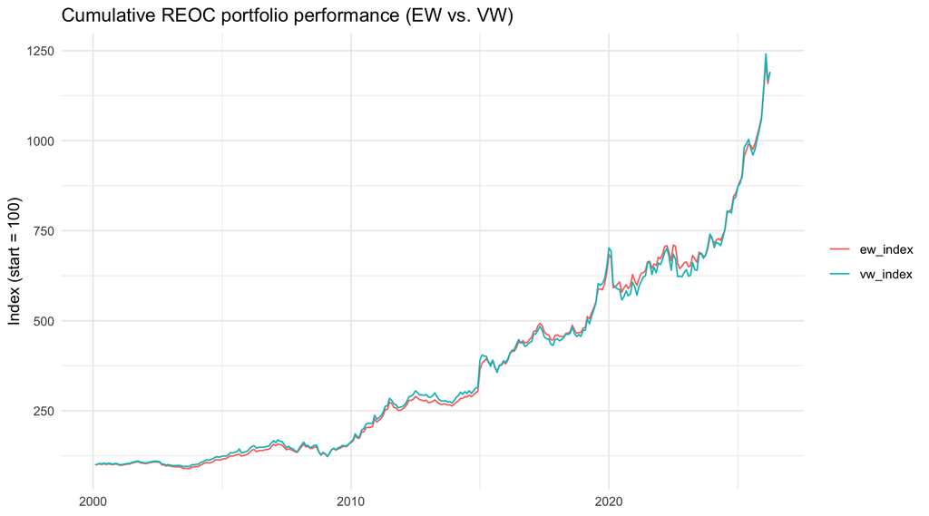

```r
portfolio_macro |>
  arrange(month) |>
  mutate(
    ew_index = 100 * cumprod(1 + ew_return) / first(cumprod(1 + ew_return)),
    vw_index = 100 * cumprod(1 + vw_return) / first(cumprod(1 + vw_return))
  ) |>
  pivot_longer(c(ew_index, vw_index), names_to = "portfolio", values_to = "index") |>
  ggplot(aes(month, index, colour = portfolio)) +
  geom_line() +
  labs(title = "Cumulative REOC portfolio performance (EW vs. VW)", x = NULL, y = "Index (start = 100)", colour = NULL)
```

# 18 18. Interest rates vs. returns

## 18.1 18.1 Contemporaneous correlation

```r
rate_corr <- portfolio_macro |>
  filter(!is.na(d_short_rate), !is.na(d_long_rate)) |>
  summarise(
    cor_ew_d_short = cor(ew_return, d_short_rate, use = "complete.obs"),
    cor_ew_d_long  = cor(ew_return, d_long_rate,  use = "complete.obs"),
    cor_vw_d_short = cor(vw_return, d_short_rate, use = "complete.obs"),
    cor_vw_d_long  = cor(vw_return, d_long_rate,  use = "complete.obs")
  )

kable(rate_corr |> mutate(across(everything(), ~ round(.x, 3))))
```

| cor_ew_d_short | cor_ew_d_long | cor_vw_d_short | cor_vw_d_long |
| --- | --- | --- | --- |
| -0.124 | -0.245 | -0.135 | -0.265 |

## 18.2 18.2 Scatter: change in long-term rate vs. portfolio return

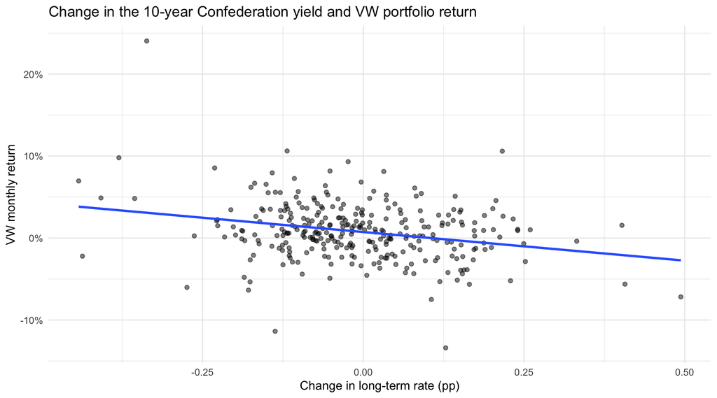

```r
portfolio_macro |>
  filter(is.finite(d_long_rate), is.finite(vw_return)) |>
  ggplot(aes(d_long_rate, vw_return)) +
  geom_point(alpha = 0.5) +
  geom_smooth(method = "lm", se = FALSE) +
  scale_y_continuous(labels = percent) +
  labs(title = "Change in the 10-year Confederation yield and VW portfolio return",
       x = "Change in long-term rate (pp)", y = "VW monthly return")
```

# 19 19. Inflation vs. returns

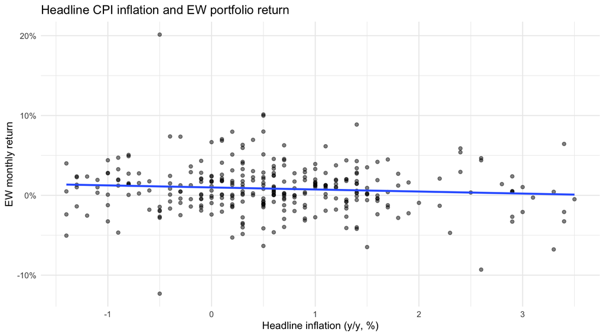

```r
portfolio_macro |>
  filter(is.finite(inflation), is.finite(ew_return)) |>
  ggplot(aes(inflation, ew_return)) +
  geom_point(alpha = 0.5) +
  geom_smooth(method = "lm", se = FALSE) +
  scale_y_continuous(labels = percent) +
  labs(title = "Headline CPI inflation and EW portfolio return",
       x = "Headline inflation (y/y, %)", y = "EW monthly return")
```

```r
tibble(
  measure = c("Headline inflation", "Core inflation (trimmed mean)"),
  cor_ew  = c(
    cor(portfolio_macro$ew_return, portfolio_macro$inflation, use = "complete.obs"),
    cor(portfolio_macro$ew_return, portfolio_macro$core_inflation, use = "complete.obs")
  ),
  cor_vw  = c(
    cor(portfolio_macro$vw_return, portfolio_macro$inflation, use = "complete.obs"),
    cor(portfolio_macro$vw_return, portfolio_macro$core_inflation, use = "complete.obs")
  )
) |>
  mutate(across(where(is.numeric), ~ round(.x, 3))) |>
  kable()
```

| measure | cor_ew | cor_vw |
| --- | --- | --- |
| Headline inflation | -0.085 | -0.064 |
| Core inflation (trimmed mean) | -0.079 | -0.061 |

# 20 20. Other macro indicators vs. returns

## 20.1 20.1 Real-estate price momentum

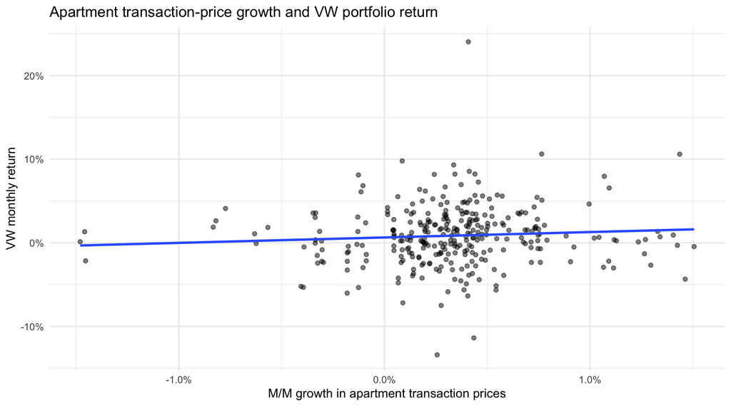

```r
portfolio_macro |>
  filter(is.finite(apartments_growth), is.finite(vw_return)) |>
  ggplot(aes(apartments_growth, vw_return)) +
  geom_point(alpha = 0.5) +
  geom_smooth(method = "lm", se = FALSE) +
  scale_x_continuous(labels = percent) +
  scale_y_continuous(labels = percent) +
  labs(title = "Apartment transaction-price growth and VW portfolio return",
       x = "M/M growth in apartment transaction prices", y = "VW monthly return")
```

## 20.2 20.2 Labour market

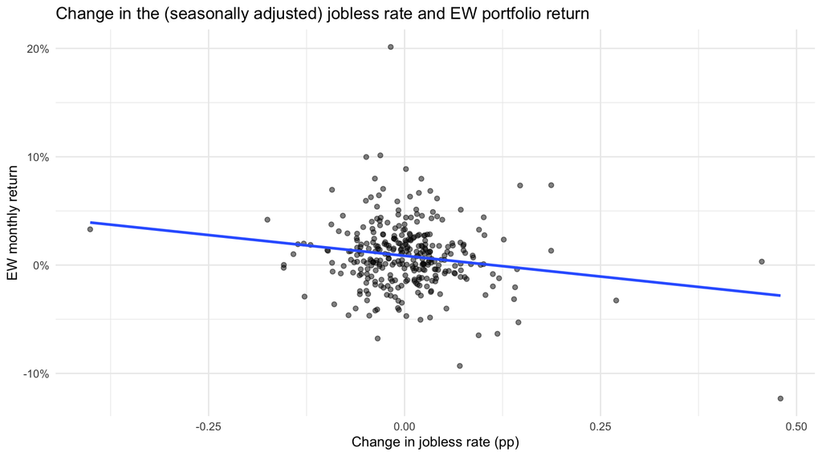

```r
portfolio_macro |>
  filter(is.finite(d_jobless_rate), is.finite(ew_return)) |>
  ggplot(aes(d_jobless_rate, ew_return)) +
  geom_point(alpha = 0.5) +
  geom_smooth(method = "lm", se = FALSE) +
  scale_y_continuous(labels = percent) +
  labs(title = "Change in the (seasonally adjusted) jobless rate and EW portfolio return",
       x = "Change in jobless rate (pp)", y = "EW monthly return")
```

# 21 21. Volatility

## 21.1 21.1 Rolling realised volatility

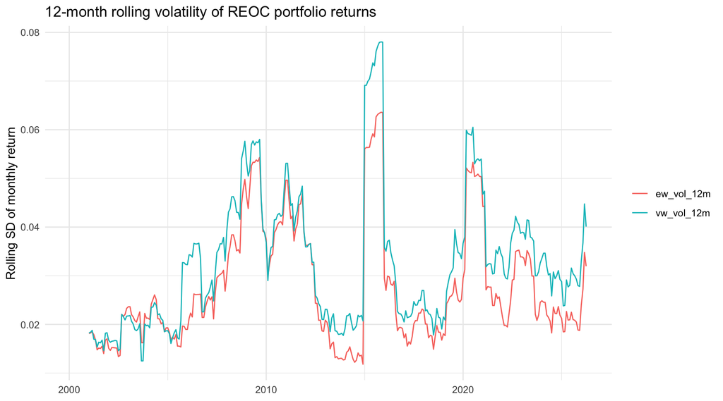

```r
portfolio_macro <- portfolio_macro |>
  arrange(month) |>
  mutate(
    ew_vol_12m = slider::slide_dbl(ew_return, sd, .before = 11, .complete = TRUE),
    vw_vol_12m = slider::slide_dbl(vw_return, sd, .before = 11, .complete = TRUE)
  )

portfolio_macro |>
  select(month, ew_vol_12m, vw_vol_12m) |>
  pivot_longer(-month, names_to = "portfolio", values_to = "vol") |>
  ggplot(aes(month, vol, colour = portfolio)) +
  geom_line(na.rm = TRUE) +
  labs(title = "12-month rolling volatility of REOC portfolio returns",
       x = NULL, y = "Rolling SD of monthly return", colour = NULL)
```

## 21.2 20.2 Volatility and interest-rate changes

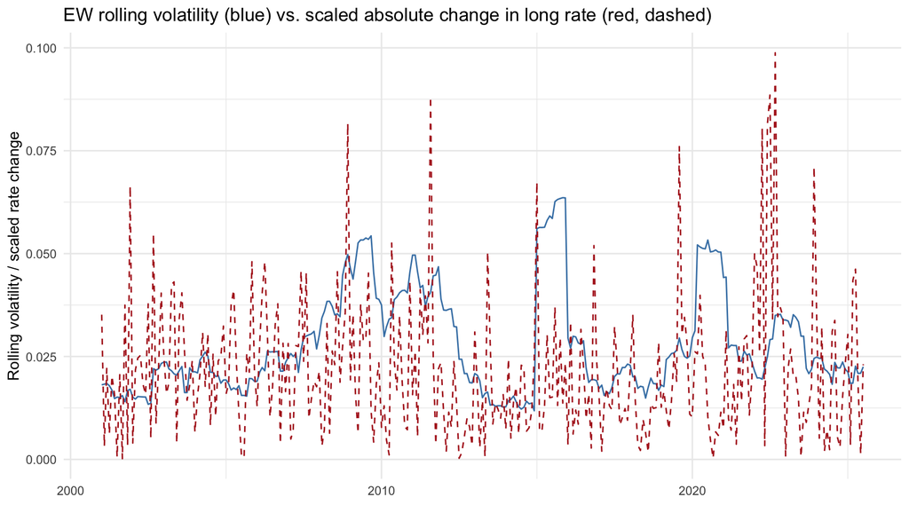

```r
portfolio_macro |>
  filter(is.finite(ew_vol_12m), is.finite(d_long_rate)) |>
  ggplot(aes(month)) +
  geom_line(aes(y = ew_vol_12m), colour = "steelblue") +
  geom_line(aes(y = abs(d_long_rate) * 0.2), colour = "firebrick", linetype = "dashed") +
  labs(title = "EW rolling volatility (blue) vs. scaled absolute change in long rate (red, dashed)",
       x = NULL, y = "Rolling volatility / scaled rate change")
```

# 22 22. Differences across time / macro regimes

```r
portfolio_macro <- portfolio_macro |>
  mutate(
    regime = case_when(
      month <  as.Date("2008-09-01") ~ "Pre-GFC (2000-2008)",
      month >= as.Date("2008-09-01") & month < as.Date("2015-01-01") ~ "Post-GFC low rates (2008-2014)",
      month >= as.Date("2015-01-01") & month < as.Date("2022-06-01") ~ "Negative-rate era (2015-2022)",
      month >= as.Date("2022-06-01") & month < as.Date("2024-01-01") ~ "Hiking cycle (2022-2023)",
      month >= as.Date("2024-01-01") ~ "Post-hiking / cuts (2024-)",
      TRUE ~ NA_character_
    ),
    regime = factor(regime, levels = c(
      "Pre-GFC (2000-2008)", "Post-GFC low rates (2008-2014)",
      "Negative-rate era (2015-2022)", "Hiking cycle (2022-2023)",
      "Post-hiking / cuts (2024-)"
    ))
  )

regime_summary <- portfolio_macro |>
  filter(!is.na(regime)) |>
  group_by(regime) |>
  summarise(
    n_months        = n(),
    mean_ew_return  = mean(ew_return, na.rm = TRUE),
    sd_ew_return    = sd(ew_return, na.rm = TRUE),
    mean_vw_return  = mean(vw_return, na.rm = TRUE),
    sd_vw_return    = sd(vw_return, na.rm = TRUE),
    mean_short_rate = mean(short_rate, na.rm = TRUE),
    mean_inflation  = mean(inflation, na.rm = TRUE),
    .groups = "drop"
  )

kable(regime_summary |> mutate(across(where(is.numeric), ~ round(.x, 4))))
```

| regime | n_months | mean_ew_return | sd_ew_return | mean_vw_return | sd_vw_return | mean_short_rate | mean_inflation |
| --- | --- | --- | --- | --- | --- | --- | --- |
| Pre-GFC (2000-2008) | 103 | 0.0041 | 0.0239 | 0.0045 | 0.0271 | 1.6943 | 1.0786 |
| Post-GFC low rates (2008-2014) | 76 | 0.0100 | 0.0346 | 0.0102 | 0.0375 | 0.2375 | 0.0250 |
| Negative-rate era (2015-2022) | 89 | 0.0098 | 0.0350 | 0.0095 | 0.0419 | -0.7431 | 0.1427 |
| Hiking cycle (2022-2023) | 19 | 0.0036 | 0.0315 | 0.0053 | 0.0390 | 1.0789 | 2.5368 |
| Post-hiking / cuts (2024-) | 28 | 0.0179 | 0.0267 | 0.0176 | 0.0347 | 0.6071 | 0.5571 |

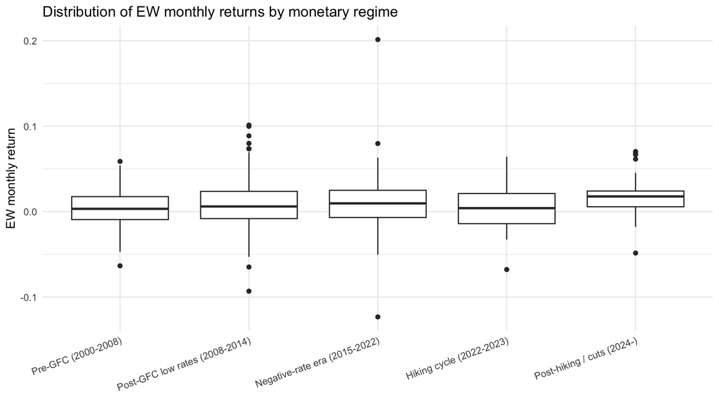

```r
portfolio_macro |>
  filter(!is.na(regime)) |>
  ggplot(aes(regime, ew_return)) +
  geom_boxplot() +
  labs(title = "Distribution of EW monthly returns by monetary regime", x = NULL, y = "EW monthly return") +
  theme(axis.text.x = element_text(angle = 20, hjust = 1))
```

# 23 23. Differences across firms

## 23.1 23.1 Firm-level sensitivity to interest rates and inflation

```r
firm_macro <- hp_macro |>
  select(ticker, month, monthly_return) |>
  left_join(
    macro_monthly |> select(month, d_short_rate, d_long_rate, inflation, d_jobless_rate),
    by = "month"
  )

firm_sensitivities <- firm_macro |>
  filter(!is.na(monthly_return)) |>
  group_by(ticker) |>
  filter(n() >= 24) |>
  nest() |>
  mutate(
    model = map(data, ~ lm(monthly_return ~ d_long_rate + inflation, data = .x)),
    tidy_model = map(model, tidy)
  ) |>
  select(ticker, tidy_model) |>
  unnest(tidy_model) |>
  filter(term %in% c("d_long_rate", "inflation")) |>
  select(ticker, term, estimate, std.error, p.value)

kable(firm_sensitivities |> mutate(across(where(is.numeric), ~ round(.x, 4))) |> arrange(term, estimate))
```

| ticker | term | estimate | std.error | p.value |
| --- | --- | --- | --- | --- |
| HIAG | d_long_rate | -0.1152 | 0.0281 | 0.0001 |
| ZUGN | d_long_rate | -0.1047 | 0.0220 | 0.0000 |
| PSPN | d_long_rate | -0.0926 | 0.0193 | 0.0000 |
| EPIC | d_long_rate | -0.0872 | 0.0234 | 0.0007 |
| IREN | d_long_rate | -0.0827 | 0.0223 | 0.0003 |
| MOBN | d_long_rate | -0.0825 | 0.0195 | 0.0000 |
| SPSN | d_long_rate | -0.0721 | 0.0186 | 0.0001 |
| ZUGEST | d_long_rate | -0.0658 | 0.0249 | 0.0091 |
| ALLN | d_long_rate | -0.0591 | 0.0161 | 0.0003 |
| ISN | d_long_rate | -0.0453 | 0.0163 | 0.0058 |
| CHAM | d_long_rate | -0.0091 | 0.0336 | 0.7886 |
| EPIC | inflation | -0.0049 | 0.0038 | 0.2036 |
| MOBN | inflation | -0.0038 | 0.0024 | 0.1123 |
| IREN | inflation | -0.0027 | 0.0029 | 0.3509 |
| ALLN | inflation | -0.0026 | 0.0021 | 0.2142 |
| HIAG | inflation | -0.0021 | 0.0033 | 0.5198 |
| SPSN | inflation | -0.0019 | 0.0024 | 0.4413 |
| ZUGEST | inflation | -0.0016 | 0.0029 | 0.5963 |
| ISN | inflation | -0.0013 | 0.0021 | 0.5429 |
| ZUGN | inflation | -0.0009 | 0.0026 | 0.7340 |
| PSPN | inflation | -0.0002 | 0.0025 | 0.9520 |
| CHAM | inflation | 0.0011 | 0.0044 | 0.8023 |

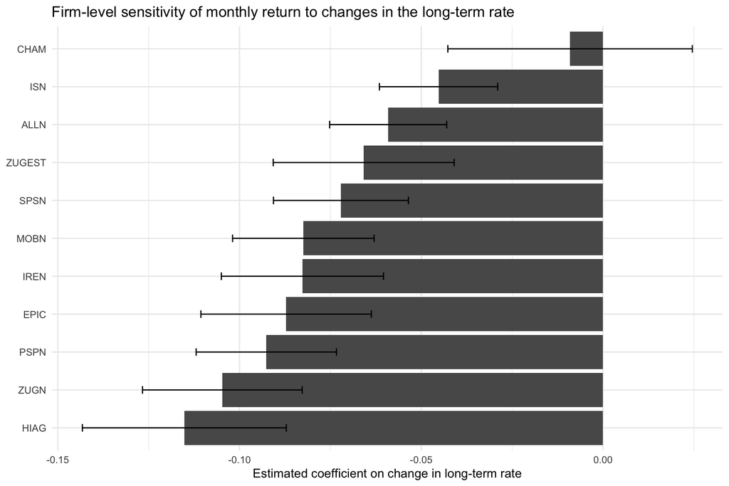

```r
firm_sensitivities |>
  filter(term == "d_long_rate") |>
  ggplot(aes(x = reorder(ticker, estimate), y = estimate)) +
  geom_col() +
  geom_errorbar(aes(ymin = estimate - std.error, ymax = estimate + std.error), width = 0.2) +
  coord_flip() +
  labs(title = "Firm-level sensitivity of monthly return to changes in the long-term rate",
       x = NULL, y = "Estimated coefficient on change in long-term rate")
```

## 23.2 23.2 A simple pooled multi-predictor regression (portfolio level)

```r
pooled_ew <- lm(ew_return ~ d_short_rate + d_long_rate + inflation + d_jobless_rate + apartments_growth, data = portfolio_macro)
pooled_vw <- lm(vw_return ~ d_short_rate + d_long_rate + inflation + d_jobless_rate + apartments_growth, data = portfolio_macro)

bind_rows(
  tidy(pooled_ew) |> mutate(portfolio = "EW"),
  tidy(pooled_vw) |> mutate(portfolio = "VW")
) |>
  select(portfolio, term, estimate, std.error, statistic, p.value) |>
  mutate(across(where(is.numeric), ~ round(.x, 4))) |>
  kable()
```

| portfolio | term | estimate | std.error | statistic | p.value |
| --- | --- | --- | --- | --- | --- |
| EW | (Intercept) | 0.0086 | 0.0023 | 3.6673 | 0.0003 |
| EW | d_short_rate | -0.0212 | 0.0129 | -1.6480 | 0.1004 |
| EW | d_long_rate | -0.0510 | 0.0130 | -3.9094 | 0.0001 |
| EW | inflation | -0.0034 | 0.0017 | -2.0552 | 0.0407 |
| EW | d_jobless_rate | -0.0997 | 0.0245 | -4.0694 | 0.0001 |
| EW | apartments_growth | 0.3054 | 0.3984 | 0.7664 | 0.4440 |
| VW | (Intercept) | 0.0083 | 0.0027 | 3.0698 | 0.0023 |
| VW | d_short_rate | -0.0274 | 0.0148 | -1.8458 | 0.0659 |
| VW | d_long_rate | -0.0635 | 0.0150 | -4.2246 | 0.0000 |
| VW | inflation | -0.0031 | 0.0019 | -1.6191 | 0.1065 |
| VW | d_jobless_rate | -0.1130 | 0.0282 | -4.0075 | 0.0001 |
| VW | apartments_growth | 0.3235 | 0.4588 | 0.7052 | 0.4812 |

# 24 24. Data-quality observations and limitations

- Rate splice: `short_rate` is spliced from `libor_3m_chf` (2000 to mid-2019) and `snb_policy_rate` (mid-2019 onward) around the SNB’s 2019 reference-rate change.
- GDP and sector output: missing roughly two-thirds of the time and excluded from the core specification.
- Real-estate price indices: FSO series are sparser than Wuest Partner series, hence the latter were used as primary proxies.
- Unbalanced firm panel: REOCs enter at different dates, so early-period portfolio statistics rest on fewer firms.
- No causal identification: all associations are descriptive/exploratory; macro variables are endogenous to each other.
- Regression caveats: plain OLS without fixed effects, clustering, or autocorrelation-robust standard errors.